# Patient Churn Prediction: End-to-End Machine Learning Analysis

## Business Problem

Patient churn can reduce continuity of care, weaken patient-provider relationships, and create operational and financial challenges for healthcare organizations. This project develops a reproducible machine-learning workflow to identify patients at risk of churn and uncover factors associated with disengagement.

## Project Objectives

1. Audit and prepare the patient churn dataset.
2. Explore churn patterns using descriptive and inferential statistics.
3. Identify statistically meaningful patient-level factors associated with churn.
4. Build and compare multiple classification algorithms using stratified cross-validation.
5. Address class imbalance with SMOTE inside the training pipeline to reduce data leakage.
6. Evaluate the selected model on an untouched test set.
7. Translate model findings into practical patient-retention recommendations.

## 1. Environment Setup

The analysis uses `pandas` and `numpy` for data manipulation, `scipy` for statistical testing, `matplotlib` for visualization, and `scikit-learn` / `imbalanced-learn` for modeling.

A fixed random seed is used throughout the workflow to make the train/test split, SMOTE sampling, and model comparisons reproducible.

```python
# STEP 1 — IMPORT LIBRARIES AND DEFINE PROJECT SETTINGS


import warnings
warnings.filterwarnings("ignore")

import numpy as np
import pandas as pd
import matplotlib.pyplot as plt

from scipy import stats
from scipy.stats import chi2_contingency

from sklearn.model_selection import train_test_split, StratifiedKFold, cross_validate
from sklearn.preprocessing import StandardScaler, OneHotEncoder
from sklearn.compose import ColumnTransformer
from sklearn.pipeline import Pipeline
from sklearn.linear_model import LogisticRegression
from sklearn.tree import DecisionTreeClassifier
from sklearn.ensemble import RandomForestClassifier
from sklearn.neighbors import KNeighborsClassifier
from sklearn.metrics import (
    accuracy_score, precision_score, recall_score, f1_score,
    roc_auc_score, confusion_matrix, classification_report,
    ConfusionMatrixDisplay, RocCurveDisplay
)

from imblearn.over_sampling import SMOTE
from imblearn.pipeline import Pipeline as ImbPipeline
from xgboost import XGBClassifier

RANDOM_STATE = 123
DATA_PATH = "patient_churn_dataset.csv"

pd.set_option("display.max_columns", None)
pd.set_option("display.float_format", lambda x: f"{x:,.4f}")
```

## 2. Load and Inspect the Data

The dataset contains 2,000 patient records and 21 variables. Initial inspection focuses on dimensions, data types, missingness, duplicates, and the churn target distribution.

```python
# STEP 2 — LOAD DATA

df = pd.read_csv(DATA_PATH)

print(f"Dataset shape: {df.shape[0]:,} rows × {df.shape[1]} columns")
display(df.head())
```

```
Dataset shape: 2,000 rows × 21 columns
```

|  | PatientID | Age | Gender | State | Tenure_Months | Specialty | Insurance_Type | Visits_Last_Year | Missed_Appointments | Days_Since_Last_Visit | Last_Interaction_Date | Overall_Satisfaction | Wait_Time_Satisfaction | Staff_Satisfaction | Provider_Rating | Avg_Out_Of_Pocket_Cost | Billing_Issues | Portal_Usage | Referrals_Made | Distance_To_Facility_Miles | Churned |
| --- | --- | --- | --- | --- | --- | --- | --- | --- | --- | --- | --- | --- | --- | --- | --- | --- | --- | --- | --- | --- | --- |
| 0 | C20000 | 41 | Female | PA | 62 | Pediatrics | Medicaid | 1 | 0 | 564 | 2024-07-05 | 3.5000 | 4.9000 | 3.8000 | 4.2000 | 306 | 0 | 0 | 3 | 21.4000 | 1 |
| 1 | C20001 | 43 | Female | GA | 44 | Internal Medicine | Self-Pay | 7 | 4 | 254 | 2025-05-11 | 2.6000 | 3.1000 | 4.7000 | 4.3000 | 1851 | 0 | 0 | 0 | 47.6000 | 1 |
| 2 | C20002 | 21 | Male | MI | 120 | Internal Medicine | Medicaid | 15 | 5 | 89 | 2025-10-23 | 1.6000 | 4.4000 | 2.1000 | 4.7000 | 391 | 0 | 0 | 2 | 7.1000 | 0 |
| 3 | C20003 | 65 | Male | FL | 118 | General Practice | Private | 10 | 3 | 135 | 2025-09-07 | 2.6000 | 4.3000 | 4.3000 | 4.9000 | 808 | 0 | 0 | 0 | 11.6000 | 1 |
| 4 | C20004 | 18 | Female | CA | 70 | Cardiology | Medicaid | 5 | 4 | 696 | 2024-02-24 | 2.2000 | 4.0000 | 4.1000 | 4.4000 | 866 | 0 | 0 | 0 | 10.3000 | 1 |

```python
# STEP 3 — DATA AUDIT

# Standardize column names to lowercase snake_case.
df.columns = (
    df.columns
      .str.strip()
      .str.lower()
      .str.replace(r"[^a-zA-Z0-9]+", "_", regex=True)
      .str.strip("_")
)

audit = pd.DataFrame({
    "dtype": df.dtypes.astype(str),
    "missing_count": df.isna().sum(),
    "missing_percent": df.isna().mean().mul(100).round(2),
    "unique_values": df.nunique()
})

display(audit)
print(f"Duplicate rows: {df.duplicated().sum():,}")
```

|  | dtype | missing_count | missing_percent | unique_values |
| --- | --- | --- | --- | --- |
| patientid | object | 0 | 0.0000 | 2000 |
| age | int64 | 0 | 0.0000 | 72 |
| gender | object | 0 | 0.0000 | 2 |
| state | object | 0 | 0.0000 | 10 |
| tenure_months | int64 | 0 | 0.0000 | 120 |
| specialty | object | 0 | 0.0000 | 7 |
| insurance_type | object | 0 | 0.0000 | 4 |
| visits_last_year | int64 | 0 | 0.0000 | 16 |
| missed_appointments | int64 | 0 | 0.0000 | 6 |
| days_since_last_visit | int64 | 0 | 0.0000 | 679 |
| last_interaction_date | object | 0 | 0.0000 | 679 |
| overall_satisfaction | float64 | 0 | 0.0000 | 36 |
| wait_time_satisfaction | float64 | 0 | 0.0000 | 36 |
| staff_satisfaction | float64 | 0 | 0.0000 | 31 |
| provider_rating | float64 | 0 | 0.0000 | 26 |
| avg_out_of_pocket_cost | int64 | 0 | 0.0000 | 1228 |
| billing_issues | int64 | 0 | 0.0000 | 2 |
| portal_usage | int64 | 0 | 0.0000 | 2 |
| referrals_made | int64 | 0 | 0.0000 | 4 |
| distance_to_facility_miles | float64 | 0 | 0.0000 | 488 |
| churned | int64 | 0 | 0.0000 | 2 |

```
Duplicate rows: 0
```

### Finding — Data Quality

The data quality analysis found no missing values and no duplicate rows , giving the project a strong starting point for modeling. The identifier (`patientid`) will be retained for traceability during exploration but will be intentionally excluded from predictive modeling because a unique ID does not represent a generalizable patient characteristic.

| churned | count | percent |
| --- | --- | --- |
| 0 | 633 | 31.6500 |
| 1 | 1367 | 68.3500 |

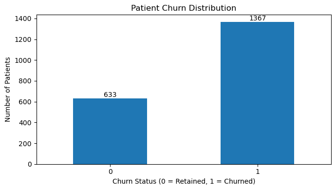

```python
# STEP 4 — TARGET DISTRIBUTION

target_summary = (
    df["churned"]
    .value_counts()
    .sort_index()
    .rename_axis("churned")
    .to_frame("count")
)

target_summary["percent"] = (
    target_summary["count"] / target_summary["count"].sum() * 100
).round(2)

display(target_summary)

ax = target_summary["count"].plot(
    kind="bar", figsize=(7, 4), rot=0,
    title="Patient Churn Distribution"
)
ax.set_xlabel("Churn Status (0 = Retained, 1 = Churned)")
ax.set_ylabel("Number of Patients")

for container in ax.containers:
    ax.bar_label(container)

plt.tight_layout()
plt.show()
```

### Finding — Class Imbalance

The dataset contained 1,367 churned patients (68.35%) and 633 retained patients (31.65%) which means we have class imbalanced. Because the class is imbalanced, accuracy alone can be misleading. The modeling stage therefore emphasizes precision, recall/sensitivity, F1 score, ROC AUC, and specificity , and applies SMOTE only within training folds.

## 3. Exploratory Data Analysis

Numerical variables are examined for distributions and potential outliers. Statistical tests then evaluate whether observed differences between churned and retained patients are unlikely to be due to random sampling variation.

```python
# STEP 5 — DEFINE ANALYTICAL FEATURES

# Exclude the target and identifier from numerical feature analysis.
numeric_features = [
    c for c in df.select_dtypes(include=np.number).columns
    if c != "churned"
]

# Exclude ID and raw date from categorical hypothesis testing.
categorical_features = [
    c for c in df.select_dtypes(include=["object", "category"]).columns
    if c not in {"patientid", "last_interaction_date"}
]

print("Numerical features:")
print(numeric_features)

print("\nCategorical features:")
print(categorical_features)
```

```
Numerical features:
['age', 'tenure_months', 'visits_last_year', 'missed_appointments', 'days_since_last_visit', 'overall_satisfaction', 'wait_time_satisfaction', 'staff_satisfaction', 'provider_rating', 'avg_out_of_pocket_cost', 'billing_issues', 'portal_usage', 'referrals_made', 'distance_to_facility_miles']

Categorical features:
['gender', 'state', 'specialty', 'insurance_type']
```

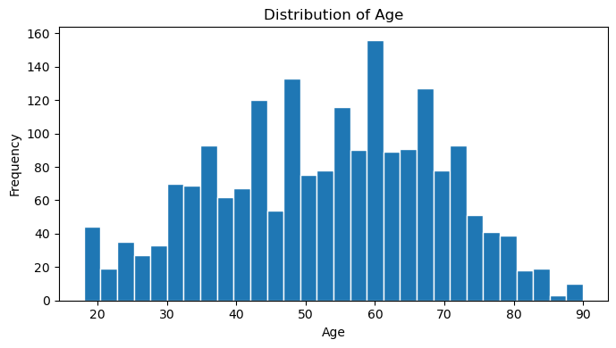

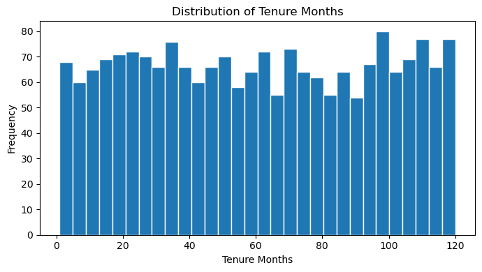

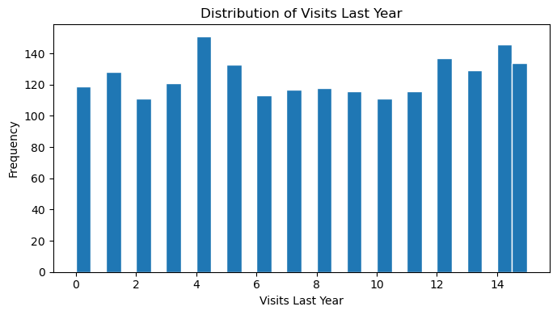

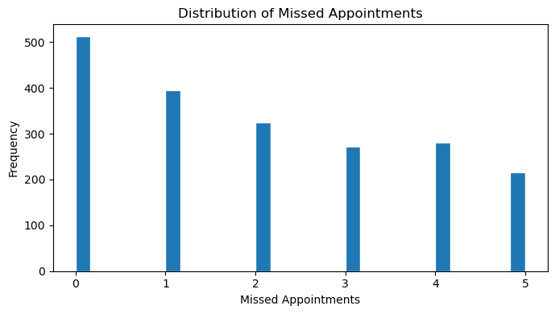

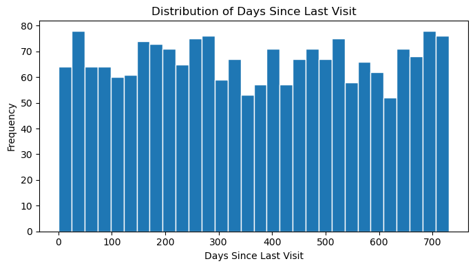

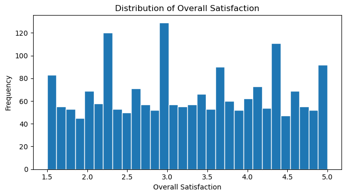

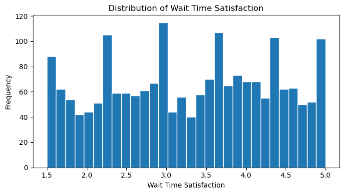

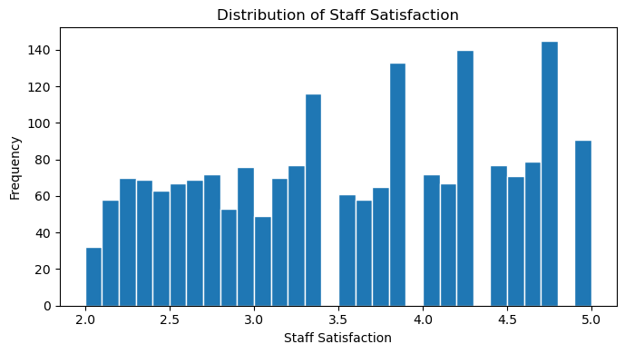

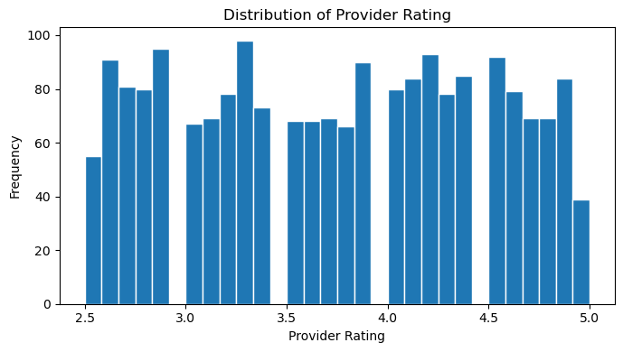

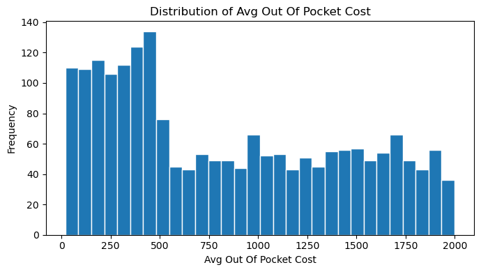

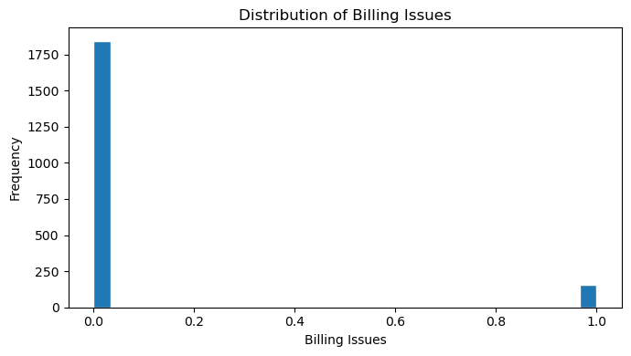

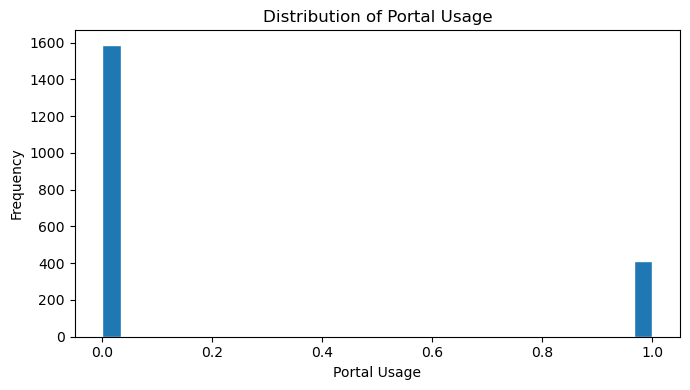

[2 more figures not shown]

```python
# STEP 6 — NUMERICAL DISTRIBUTIONS

for column in numeric_features:
    fig, ax = plt.subplots(figsize=(7, 4))
    ax.hist(df[column].dropna(), bins=30, edgecolor="white")
    ax.set_title(f"Distribution of {column.replace('_', ' ').title()}")
    ax.set_xlabel(column.replace("_", " ").title())
    ax.set_ylabel("Frequency")
    plt.tight_layout()
    plt.show()
```

```python
# STEP 7 — IQR-BASED OUTLIER SCREENING

def count_iqr_outliers(series):
    """Count observations outside the conventional 1.5 × IQR bounds."""
    q1 = series.quantile(0.25)
    q3 = series.quantile(0.75)
    iqr = q3 - q1
    lower = q1 - 1.5 * iqr
    upper = q3 + 1.5 * iqr
    return ((series < lower) | (series > upper)).sum()

outlier_summary = pd.DataFrame({
    "variable": numeric_features,
    "outlier_count": [count_iqr_outliers(df[c].dropna()) for c in numeric_features]
}).sort_values("outlier_count", ascending=False)

display(outlier_summary)
```

|  | variable | outlier_count |
| --- | --- | --- |
| 11 | portal_usage | 412 |
| 10 | billing_issues | 157 |
| 0 | age | 0 |
| 1 | tenure_months | 0 |
| 2 | visits_last_year | 0 |
| 3 | missed_appointments | 0 |
| 4 | days_since_last_visit | 0 |
| 5 | overall_satisfaction | 0 |
| 6 | wait_time_satisfaction | 0 |
| 7 | staff_satisfaction | 0 |
| 8 | provider_rating | 0 |
| 9 | avg_out_of_pocket_cost | 0 |
| 12 | referrals_made | 0 |
| 13 | distance_to_facility_miles | 0 |

### Finding — Outlier Screening

The IQR screen flagged portal usage (412 observations) and billing issues (157 observations). This is due to the fact their are binary

## 4. Statistical Relationship With Churn

Welch's independent-samples t-test is used for numerical variables because it does not require equal group variances. Chi-square tests are used for categorical variables. Statistical significance is interpreted at α = 0.05.

Statistical association does not imply causation. These tests are used as exploratory evidence, not as proof that a variable causes churn.

```python
# STEP 8 — WELCH'S T-TEST: NUMERICAL FEATURES VS CHURN

t_test_results = []

for column in numeric_features:
    retained = df.loc[df["churned"] == 0, column].dropna()
    churned = df.loc[df["churned"] == 1, column].dropna()

    t_stat, p_value = stats.ttest_ind(
        retained, churned, equal_var=False
    )

    t_test_results.append({
        "variable": column,
        "retained_mean": retained.mean(),
        "churned_mean": churned.mean(),
        "t_statistic": t_stat,
        "p_value": p_value,
        "significant_at_0.05": p_value < 0.05
    })

t_test_df = (
    pd.DataFrame(t_test_results)
      .sort_values("p_value")
      .reset_index(drop=True)
)

display(t_test_df)
```

|  | variable | retained_mean | churned_mean | t_statistic | p_value | significant_at_0.05 |
| --- | --- | --- | --- | --- | --- | --- |
| 0 | overall_satisfaction | 3.4831 | 3.1494 | 6.9642 | 0.0000 | True |
| 1 | days_since_last_visit | 339.1406 | 378.6277 | -3.8697 | 0.0001 | True |
| 2 | wait_time_satisfaction | 3.4073 | 3.2356 | 3.5743 | 0.0004 | True |
| 3 | tenure_months | 64.8468 | 58.8288 | 3.5739 | 0.0004 | True |
| 4 | distance_to_facility_miles | 23.6265 | 25.8809 | -3.3681 | 0.0008 | True |
| 5 | portal_usage | 0.2496 | 0.1858 | 3.1618 | 0.0016 | True |
| 6 | missed_appointments | 1.8547 | 2.1083 | -3.1592 | 0.0016 | True |
| 7 | age | 54.3207 | 52.1785 | 2.8929 | 0.0039 | True |
| 8 | billing_issues | 0.0569 | 0.0885 | -2.6375 | 0.0084 | True |
| 9 | avg_out_of_pocket_cost | 787.7346 | 859.1456 | -2.5600 | 0.0106 | True |
| 10 | provider_rating | 3.7945 | 3.7091 | 2.4655 | 0.0138 | True |
| 11 | visits_last_year | 7.2591 | 7.7783 | -2.3002 | 0.0216 | True |
| 12 | referrals_made | 1.5482 | 1.4535 | 1.7961 | 0.0727 | False |
| 13 | staff_satisfaction | 3.4855 | 3.5446 | -1.4128 | 0.1580 | False |

### Finding — Numerical Factors Associated With Churn

The Whech t-test identified statistically significant differences for overall satisfaction, days since last visit, wait-time satisfaction, tenure, distance to facility, portal usage, missed appointments, age, billing issues, average out-of-pocket cost, provider rating, and visits in the last year.

The strongest statistical signal was overall satisfaction (p ≈0.00000), followed by days since last visit and wait-time satisfaction. Referrals made and staff satisfaction were not statistically significant at the 0.05 level in that analysis.

```python
# STEP 9 — CHI-SQUARE TEST: CATEGORICAL FEATURES VS CHURN

chi_square_results = []

for column in categorical_features:
    table = pd.crosstab(df[column], df["churned"])
    chi2, p_value, dof, expected = chi2_contingency(table)

    chi_square_results.append({
        "variable": column,
        "chi_square": chi2,
        "degrees_of_freedom": dof,
        "p_value": p_value,
        "significant_at_0.05": p_value < 0.05
    })

chi_square_df = (
    pd.DataFrame(chi_square_results)
      .sort_values("p_value")
      .reset_index(drop=True)
)

display(chi_square_df)
```

|  | variable | chi_square | degrees_of_freedom | p_value | significant_at_0.05 |
| --- | --- | --- | --- | --- | --- |
| 0 | specialty | 5.2948 | 6 | 0.5066 | False |
| 1 | insurance_type | 2.2963 | 3 | 0.5132 | False |
| 2 | gender | 0.3401 | 1 | 0.5598 | False |
| 3 | state | 3.8018 | 9 | 0.9240 | False |

### Finding — Categorical Variables

According to Chi_square test, specialty, insurance type, gender, and state were not statistically significant predictors of churn in univariate chi-square tests (all p > 0.05).

Patientid` and the raw interaction date are not chi-square tested because a unique identifier has no meaningful categorical relationship to generalizable churn behavior, while raw dates with many unique values are better transformed into useful time features.

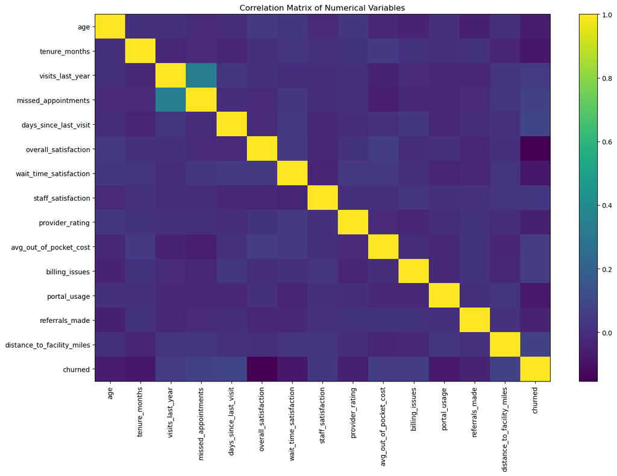

```python
# STEP 10 — CORRELATION MATRIX

corr = df[numeric_features + ["churned"]].corr()

fig, ax = plt.subplots(figsize=(14, 10))
image = ax.imshow(corr, aspect="auto")
fig.colorbar(image)

ax.set_xticks(range(len(corr.columns)))
ax.set_xticklabels(corr.columns, rotation=90)
ax.set_yticks(range(len(corr.columns)))
ax.set_yticklabels(corr.columns)
ax.set_title("Correlation Matrix of Numerical Variables")

plt.tight_layout()
plt.show()
```

```python
# Extract correlations specifically with the churn outcome.
# Absolute correlation is added so variables can be ranked by
# relationship strength regardless of direction.

churn_correlations = (
    corr["churned"]
    .drop("churned")
    .to_frame(name="correlation_with_churn")
)

churn_correlations["absolute_correlation"] = (
    churn_correlations["correlation_with_churn"].abs()
)

churn_correlations = churn_correlations.sort_values(
    "absolute_correlation",
    ascending=False
)

display(churn_correlations)
```

|  | correlation_with_churn | absolute_correlation |
| --- | --- | --- |
| overall_satisfaction | -0.1539 | 0.1539 |
| days_since_last_visit | 0.0863 | 0.0863 |
| tenure_months | -0.0797 | 0.0797 |
| wait_time_satisfaction | -0.0792 | 0.0792 |
| distance_to_facility_miles | 0.0752 | 0.0752 |
| portal_usage | -0.0734 | 0.0734 |
| missed_appointments | 0.0694 | 0.0694 |
| age | -0.0629 | 0.0629 |
| avg_out_of_pocket_cost | 0.0564 | 0.0564 |
| billing_issues | 0.0547 | 0.0547 |
| provider_rating | -0.0541 | 0.0541 |
| visits_last_year | 0.0517 | 0.0517 |
| referrals_made | -0.0400 | 0.0400 |
| staff_satisfaction | 0.0316 | 0.0316 |

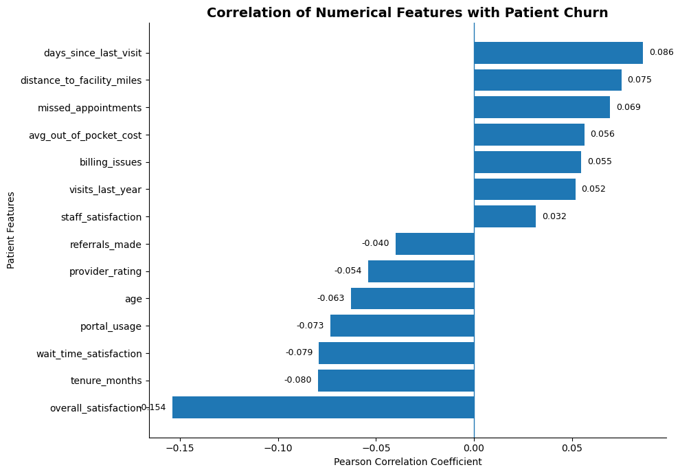

```python
# STEP 10B — CORRELATION WITH PATIENT CHURN BAR CHART


# Sort correlations from the strongest positive relationship
# to the strongest negative relationship.
plot_corr = (
    churn_correlations
    .sort_values("correlation_with_churn")
)

# Create a horizontal bar chart.
fig, ax = plt.subplots(figsize=(10, 7))

ax.barh(
    plot_corr.index,
    plot_corr["correlation_with_churn"]
)

# Add a reference line at zero to clearly separate
# positive and negative correlations.
ax.axvline(0, linewidth=1)

# Add correlation values at the end of each bar.
for i, value in enumerate(plot_corr["correlation_with_churn"]):
    ax.text(
        value + (0.003 if value >= 0 else -0.003),
        i,
        f"{value:.3f}",
        va="center",
        ha="left" if value >= 0 else "right",
        fontsize=9
    )

# Professional chart formatting.
ax.set_title(
    "Correlation of Numerical Features with Patient Churn",
    fontsize=14,
    fontweight="bold"
)

ax.set_xlabel("Pearson Correlation Coefficient")
ax.set_ylabel("Patient Features")

# Remove unnecessary borders for a cleaner portfolio-style chart.
ax.spines["top"].set_visible(False)
ax.spines["right"].set_visible(False)

plt.tight_layout()
plt.show()
```

**Finding — Correlation Analysis**

The correlation matrix shows that most numerical predictors have weak pairwise linear relationships with one another, suggesting that severe multicollinearity is not a major concern in the dataset. This is useful because the variables appear to capture different dimensions of the patient experience rather than repeatedly measuring the same underlying characteristic.

For the churn outcome specifically, the strongest relationships are still relatively modest. Variables such as Overall Satisfaction, Days Since Last Visit, Wait Time Satisfaction, Tenure Months, Distance, Portal Usage, and Missed Appointments show more noticeable relationships with churn than many of the other numerical variables. This pattern is consistent with the statistical testing, where several of these variables were also significantly different between churned and retained patients.

Patient churn does not appear to be driven by one overwhelmingly dominant numerical variable. Instead, churn is likely influenced by a combination of satisfaction, engagement, healthcare utilization, access, and financial factors, supporting the use of multivariable machine-learning models.

## 5. Machine Learning Preparation

The modeling workflow intentionally separates training from testing before learning preprocessing transformations. This protects the final test set from leakage.

Important design choices:

- `patientid` is removed from model features.
- `last_interaction_date` is transformed into year, month, and day-of-week features.
- Numerical variables are standardized.
- Categorical variables are one-hot encoded.
- SMOTE is applied inside the imbalanced-learn pipeline, meaning synthetic observations are generated only from each training fold during cross-validation.

```python
# STEP 11 — FEATURE ENGINEERING

model_df = df.copy()

# Convert date safely and derive potentially useful calendar features.
model_df["last_interaction_date"] = pd.to_datetime(
    model_df["last_interaction_date"], errors="coerce"
)

model_df["interaction_year"] = model_df["last_interaction_date"].dt.year
model_df["interaction_month"] = model_df["last_interaction_date"].dt.month
model_df["interaction_dayofweek"] = model_df["last_interaction_date"].dt.dayofweek

# Remove the raw date and patient identifier.
model_df = model_df.drop(
    columns=["last_interaction_date", "patientid"],
    errors="ignore"
)

X = model_df.drop(columns="churned")
y = model_df["churned"]

print(f"Modeling matrix: {X.shape}")
```

```
Modeling matrix: (2000, 21)
```

```python
# STEP 12 — STRATIFIED 80/20 TRAIN/TEST SPLIT

X_train, X_test, y_train, y_test = train_test_split(
    X,
    y,
    test_size=0.20,
    random_state=RANDOM_STATE,
    stratify=y
)

print("Training class distribution:")
display(y_train.value_counts(normalize=True).rename("proportion").to_frame())

print("Testing class distribution:")
display(y_test.value_counts(normalize=True).rename("proportion").to_frame())
```

```
Training class distribution:
```

| churned | proportion |
| --- | --- |
| 1 | 0.6837 |
| 0 | 0.3162 |

```
Testing class distribution:
```

| churned | proportion |
| --- | --- |
| 1 | 0.6825 |
| 0 | 0.3175 |

```python
# STEP 13 — PREPROCESSING PIPELINE

numeric_model_features = X_train.select_dtypes(include=np.number).columns.tolist()
categorical_model_features = X_train.select_dtypes(
    include=["object", "category"]
).columns.tolist()

numeric_transformer = Pipeline([
    ("scaler", StandardScaler())
])

categorical_transformer = Pipeline([
    ("onehot", OneHotEncoder(handle_unknown="ignore"))
])

preprocessor = ColumnTransformer([
    ("numeric", numeric_transformer, numeric_model_features),
    ("categorical", categorical_transformer, categorical_model_features)
])

print(f"Numerical model features: {len(numeric_model_features)}")
print(f"Categorical model features: {len(categorical_model_features)}")
```

```
Numerical model features: 17
Categorical model features: 4
```

## 6. Model Development and Cross-Validation

Five classifiers are compared:

- Logistic Regression — interpretable linear baseline
- Decision Tree — nonlinear rule-based model
- Random Forest — ensemble of randomized decision trees
- K-Nearest Neighbors — distance-based classifier
- XGBoost — gradient-boosted tree ensemble

The comparison uses 5-fold stratified cross-validation so each fold maintains approximately the same churn proportion.

```python
# STEP 14 — DEFINE CANDIDATE MODELS

models = {
    "Logistic Regression": LogisticRegression(
        max_iter=1000, random_state=RANDOM_STATE
    ),
    "Decision Tree": DecisionTreeClassifier(
        random_state=RANDOM_STATE
    ),
    "Random Forest": RandomForestClassifier(
        n_estimators=500,
        random_state=RANDOM_STATE,
        n_jobs=1
    ),
    "KNN": KNeighborsClassifier(n_neighbors=5),
    "XGBoost": XGBClassifier(
        random_state=RANDOM_STATE,
        eval_metric="logloss"
    )
}

cv = StratifiedKFold(
    n_splits=5,
    shuffle=True,
    random_state=RANDOM_STATE
)

scoring = {
    "accuracy": "accuracy",
    "precision": "precision",
    "recall": "recall",
    "f1": "f1",
    "roc_auc": "roc_auc"
}
```

```python
# STEP 15 — CROSS-VALIDATE EVERY MODEL

cv_results = []

for model_name, estimator in models.items():

    # SMOTE is deliberately inside the pipeline.
    # This prevents synthetic samples from leaking across CV folds.
    pipeline = ImbPipeline([
        ("preprocessor", preprocessor),
        ("smote", SMOTE(random_state=RANDOM_STATE)),
        ("model", estimator)
    ])

    scores = cross_validate(
        pipeline,
        X_train,
        y_train,
        cv=cv,
        scoring=scoring,
        n_jobs=-1
    )

    cv_results.append({
        "Model": model_name,
        "Accuracy": scores["test_accuracy"].mean(),
        "Precision": scores["test_precision"].mean(),
        "Sensitivity": scores["test_recall"].mean(),
        "F1 Score": scores["test_f1"].mean(),
        "ROC AUC": scores["test_roc_auc"].mean()
    })

cv_results_df = (
    pd.DataFrame(cv_results)
      .sort_values(["F1 Score", "ROC AUC"], ascending=False)
      .reset_index(drop=True)
)

display(cv_results_df.style.format({
    "Accuracy": "{:.3f}",
    "Precision": "{:.3f}",
    "Sensitivity": "{:.3f}",
    "F1 Score": "{:.3f}",
    "ROC AUC": "{:.3f}"
}))
```

|  | Model | Accuracy | Precision | Sensitivity | F1 Score | ROC AUC |
| --- | --- | --- | --- | --- | --- | --- |
| 0 | Random Forest | 0.661 | 0.695 | 0.900 | 0.784 | 0.600 |
| 1 | XGBoost | 0.631 | 0.701 | 0.802 | 0.748 | 0.567 |
| 2 | Logistic Regression | 0.604 | 0.763 | 0.615 | 0.680 | 0.632 |
| 3 | Decision Tree | 0.554 | 0.686 | 0.643 | 0.663 | 0.503 |
| 4 | KNN | 0.477 | 0.711 | 0.396 | 0.508 | 0.531 |

## 7. Final Model Evaluation on Untouched Test Data

The highest-F1 cross-validation model is refit using the complete training set and then evaluated once on the untouched 20% test set. This produces a more realistic estimate of out-of-sample performance.

```python
# STEP 16 — SELECT AND FIT THE FINAL MODEL

best_model_name = cv_results_df.loc[0, "Model"]
best_classifier = models[best_model_name]

final_model = ImbPipeline([
    ("preprocessor", preprocessor),
    ("smote", SMOTE(random_state=RANDOM_STATE)),
    ("model", best_classifier)
])

final_model.fit(X_train, y_train)

y_pred = final_model.predict(X_test)
y_prob = final_model.predict_proba(X_test)[:, 1]

print(f"Selected model: {best_model_name}")
```

```
Selected model: Random Forest
```

```python
# STEP 17 — TEST-SET PERFORMANCE

tn, fp, fn, tp = confusion_matrix(y_test, y_pred).ravel()

test_metrics = pd.Series({
    "Accuracy": accuracy_score(y_test, y_pred),
    "Precision": precision_score(y_test, y_pred),
    "Sensitivity / Recall": recall_score(y_test, y_pred),
    "Specificity": tn / (tn + fp),
    "F1 Score": f1_score(y_test, y_pred),
    "ROC AUC": roc_auc_score(y_test, y_prob)
}, name="Test Performance")

display(test_metrics.to_frame().style.format("{:.3f}"))

print("\nClassification Report")
print(classification_report(y_test, y_pred, digits=3))
```

|  | Test Performance |
| --- | --- |
| Accuracy | 0.672 |
| Precision | 0.699 |
| Sensitivity / Recall | 0.912 |
| Specificity | 0.157 |
| F1 Score | 0.792 |
| ROC AUC | 0.609 |

```
Classification Report
              precision    recall  f1-score   support

           0      0.455     0.157     0.234       127
           1      0.699     0.912     0.792       273

    accuracy                          0.672       400
   macro avg      0.577     0.535     0.513       400
weighted avg      0.622     0.672     0.615       400
```

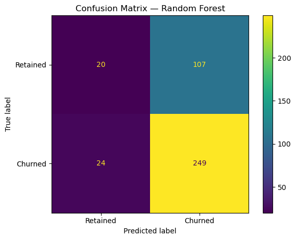

```python
# STEP 18 — CONFUSION MATRIX

ConfusionMatrixDisplay.from_predictions(
    y_test,
    y_pred,
    display_labels=["Retained", "Churned"],
    values_format="d"
)
plt.title(f"Confusion Matrix — {best_model_name}")
plt.tight_layout()
plt.show()
```

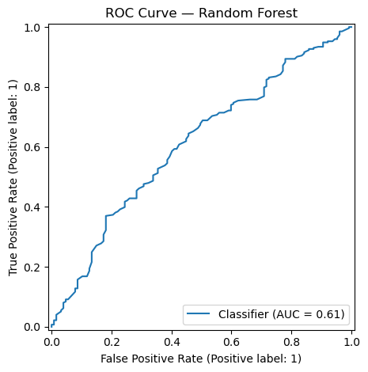

```python
# STEP 19 — ROC CURVE

RocCurveDisplay.from_predictions(y_test, y_prob)
plt.title(f"ROC Curve — {best_model_name}")
plt.tight_layout()
plt.show()
```

### Finding — Final Random Forest Performance From the Original Run

The original test-set evaluation reported approximately:

[output not shown]

The Random Forest captured most churned patients, which explains its excellent sensitivity. However, the very low specificity shows that it also classified many retained patients as churn risks.

This model is useful as a high-recall screening model, but it should not be presented as a fully optimized production classifier. A healthcare organization using it operationally would likely want threshold tuning, probability calibration, hyperparameter optimization, and cost-sensitive evaluation to reduce unnecessary interventions among patients who would otherwise remain.

## 8. Random Forest Feature Importance

To better understand the selected Random Forest model, feature importance is examined to identify which patient characteristics contributed most to churn predictions.

This step also allows us to compare the machine-learning findings with the variables identified during exploratory data analysis and statistical testing.

```python
# Extract the fitted preprocessing step and Random Forest model
fitted_preprocessor = final_model.named_steps["preprocessor"]
rf_model = final_model.named_steps["model"]

# Get feature names after preprocessing
feature_names = fitted_preprocessor.get_feature_names_out()

# Create feature importance table
feature_importance = pd.DataFrame({
    "Feature": feature_names,
    "Importance": rf_model.feature_importances_
})
## remove prefix numeric or categorical
feature_importance["Feature"] = (
    feature_importance["Feature"]
    .str.replace("numeric__", "", regex=False)
    .str.replace("categorical__", "", regex=False)
    .str.replace("num__", "", regex=False)
    .str.replace("cat__", "", regex=False)
)

# Rank features from most important to least important
feature_importance = (
    feature_importance
    .sort_values("Importance", ascending=False)
    .reset_index(drop=True)
)

# Add ranking
feature_importance["Rank"] = np.arange(
    1, len(feature_importance) + 1
)

# Display Top 20
display(feature_importance.head(20))
```

|  | Feature | Importance | Rank |
| --- | --- | --- | --- |
| 0 | overall_satisfaction | 0.0638 | 1 |
| 1 | distance_to_facility_miles | 0.0607 | 2 |
| 2 | tenure_months | 0.0596 | 3 |
| 3 | wait_time_satisfaction | 0.0595 | 4 |
| 4 | avg_out_of_pocket_cost | 0.0591 | 5 |
| 5 | age | 0.0540 | 6 |
| 6 | days_since_last_visit | 0.0516 | 7 |
| 7 | staff_satisfaction | 0.0488 | 8 |
| 8 | provider_rating | 0.0474 | 9 |
| 9 | interaction_month | 0.0441 | 10 |
| 10 | visits_last_year | 0.0432 | 11 |
| 11 | missed_appointments | 0.0432 | 12 |
| 12 | interaction_dayofweek | 0.0348 | 13 |
| 13 | referrals_made | 0.0312 | 14 |
| 14 | insurance_type_Private | 0.0216 | 15 |
| 15 | insurance_type_Medicaid | 0.0204 | 16 |
| 16 | specialty_Cardiology | 0.0194 | 17 |
| 17 | specialty_Orthopedics | 0.0161 | 18 |
| 18 | insurance_type_Self-Pay | 0.0156 | 19 |
| 19 | insurance_type_Medicare | 0.0138 | 20 |

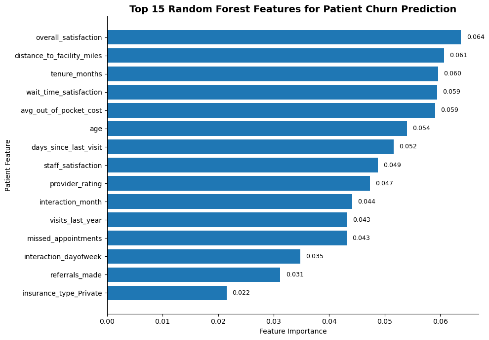

```python
# Select the 15 most influential features.
top_features = (
    feature_importance
    .head(15)
    .sort_values("Importance")
)

fig, ax = plt.subplots(figsize=(10, 7))

ax.barh(
    top_features["Feature"],
    top_features["Importance"]
)

# Add importance score next to each bar.
for i, value in enumerate(top_features["Importance"]):
    ax.text(
        value + 0.001,
        i,
        f"{value:.3f}",
        va="center",
        fontsize=9
    )

ax.set_title(
    "Top 15 Random Forest Features for Patient Churn Prediction",
    fontsize=14,
    fontweight="bold"
)

ax.set_xlabel("Feature Importance")
ax.set_ylabel("Patient Feature")

ax.spines["top"].set_visible(False)
ax.spines["right"].set_visible(False)

plt.tight_layout()
plt.show()
```

Findings :Random Forest feature importance was examined to determine which patient characteristics contributed most to the model's churn predictions. Several of the variables identified during exploratory and statistical analysis also appeared among the model's most influential predictors.

This overlap provides additional evidence that the patterns identified during EDA are not only statistically detectable but also useful for predicting patient churn. In particular, variables related to patient satisfaction, recency of care, engagement, healthcare utilization, accessibility, and financial experience contribute to the model's predictions.

## 9. Business Insights and Retention Opportunities

The statistical analysis suggests that churn is more strongly associated with patient experience and engagement variables than with broad demographic categories.

Potential retention actions include:

- Prioritize low-satisfaction patients: Overall satisfaction produced the strongest univariate statistical signal.
- Re-engage inactive patients: Longer time since the last visit was significantly associated with churn.
- Improve waiting experience: Wait-time satisfaction showed a meaningful relationship with churn.
- Monitor missed appointments: Repeated missed visits can be used as an early-warning signal.
- Investigate access barriers: Distance to the facility and out-of-pocket costs may identify patients facing practical or financial friction.
- Use digital engagement carefully: Portal usage was statistically associated with churn and may help segment patients by engagement behavior.

These recommendations are hypotheses for operational testing; the observational dataset does not establish causal effects.

## 10. Limitations and Next Steps

The current results are promising for a portfolio demonstration, but several improvements would strengthen a production-oriented version:

- Tune Random Forest and XGBoost hyperparameters with nested or carefully designed cross-validation.
- Tune the classification threshold using business costs for false positives and false negatives.
- Add PR AUC, especially because churn is imbalanced.
- Examine probability calibration.
- Use SHAP or permutation importance for model explainability.
- Test class weighting as an alternative to SMOTE.
- Evaluate temporal validation if future patient records become available.
- Add fairness diagnostics across demographic groups before operational use.
- Package preprocessing and inference into a reusable prediction function or API.

## Conclusion

This project demonstrates an end-to-end machine-learning workflow for patient churn prediction, combining data quality assessment, exploratory analysis, statistical inference, feature engineering, imbalance handling, cross-validation, and out-of-sample evaluation.

The strongest analytical insight is that patient churn appears more closely connected to satisfaction, recency of care, engagement, access, and service experience than to the tested broad categorical characteristics. The selected Random Forest model achieved strong churn sensitivity but weak specificity, making it better suited to risk screening than autonomous decision-making in its current form.

The project therefore shows both predictive modeling capability and an important professional skill: evaluating a model according to its real-world trade-offs rather than relying on a single headline metric.